# 3-3: Stochastic births and deaths model

## Overview

*In this practical you will see how we can make the code for the stochastic birth-death model safer, simpler, and more reusable.*

## Background

When running stochastic simulations we often want to run multiple simulations and compare outputs easily. In this practical we will learn how to efficiently plot multiple outputs on the same graph, and use a new set of functions contained within the IBAHCM/RPiR package on GitHub.

## Tasks

You can look at the code used to generate this package on GitHub at https://github.com/IBAHCM/RPiR. Take a look at this code online and read the following explanation.

Remember that in the previous practical the program repeated a section of code to overlay another output on the graph:

```r
#' Section: And again!
#' -------------------
population.df <- data.frame(time = start.time,
                            count = initial.count)

latest.population <- population.df
keep.going <- latest.population$time < end.time

while (keep.going) {
  data <- timestep_stochastic_birth_death(latest.population,
                                          human.annual.birth,
                                          human.annual.death,
                                          short.timestep)
  latest.population <- data$updated.pop
  population.df <- rbind(population.df, latest.population)
  keep.going <- (!data$end.experiment) && (latest.population$time < end.time)
}

plot_populations(population.df, new.graph = FALSE, lty = 2)
```

**It is bad practice to be copying and pasting identical code** as we can easily introduce mistakes. So we should try to separate the simulation functionality from the model more cleanly. Take a look at the new function `run_simple()` online. Go to https://github.com/IBAHCM/RPiR, open on the R folder, and find the file called run_simple.R. It should look something like this:

```r
#' @title Simplest code to run a simulation loop #'
#' @description
#' A generic function to run a simulation loop for a fixed period of time.
#'
#' @param step_function Function to run a timestep (step_function())
#' which returns a list containing elements updated.pop} with the
#' updated population and end.experiment which is TRUE if
#' the experiment has ended (FALSE if not)
#' @param initial.pop Initial population data frame with columns corresponding
#' to function requirements
#' @param end.time End of time simulation
#' @param ... (optional) any other arguments for step_function(), e.g.
#' parameters or timestep
#'
#' @return Data frame containing population history of simulation over time
run_simple <- function(step_function,
                       initial.pop,
                       end.time,
                       ...) {
  # Check whether step_function uses global variables
  if (length(findGlobals(step_function, merge = FALSE)$variables) > 0)
    warning(paste("Function provided uses global variable(s):",
                  paste(findGlobals(step_function, merge = FALSE)$variables,
                        collapse = ", ")))
  population.df <- latest.df <- initial.pop
  keep.going <- (latest.df$time < end.time)
  while (keep.going) {
    data <- step_function(latest.df, ...)
    latest.df <- data$updated.pop
    population.df <- rbind(population.df, latest.df)
    keep.going <- (latest.df$time < end.time) && (!data$end.experiment)
  }
  row.names(population.df) <- NULL
  population.df
}
```

The purpose of this new function is to separate out the simulation functionality from the model, and to simplify and automate the running of multiple stochastic simulations. If you look closely you can see that the function `run_simple()` does the job we described in the And again! section (at the top of this page). It is set up in terms of the generically named `step_function()` – in the case of the current model we would be using `timestep_stochastic_birth_death()` when we call `run_simple()`:

```r
final.populations <- run_simple(timestep_stochastic_birth_death,
                                initial.populations,
                                end.time,
                                birth.rate = human.annual.birth,
                                death.rate = human.annual.death,
                                timestep = short.timestep)
```

There are two things going on here that we haven’t seen before: (1) We’re passing the step function as an argument to the `run_simple()` function. This just happens like any other argument being passed, you pass in the function, it gets assigned to the `step_function` argument – remember that we can call it anything inside a function – and then `step_function` gets used just like `initial.pop` and all of the other arguments. (2) the argument `...`. This is a way of saying “and there will be other arguments I don’t want to (or can’t) specify”. You will find this in lots of R code (see `?plot` for example). For us, the point is that *each step function will need different parameters* *passed to it, and we don’t know what they are in advance*. Instead we just pass them through:

```r
data <- step_function(initial.pop, ...)
```

**Any arguments after the three fixed arguments to** `run_simple()` **must be named** – they will be passed straight through to the step function (via the `...`).

### demo/d0303_run_birth_death.R

Now write a new demo called d0303_run_birth_death using `run_simple()` to replace the whole simulation loop in the earlier code. This should make the code in d0302_stochastic_birth_death more compact, and will also make it much less prone to error, as we’ve isolated 10 more lines of code that we never need to write (or copy and paste) again.

If you encounter any problems, {RPiR} has a function, `run_simulation()`, that does some additional checking and reporting if you set an additional argument `debug = TRUE`, which may help you identify what’s going wrong. We’ve mostly suggested using `run_simple()` here as it’s significantly easier to follow what’s going on in the function, but in future exercises, it’s better to use `run_simulation()` for everything as it has some other additional functionality.

## Running the code / Report

Run the code and observe the variability in outputs. You should get something like this:

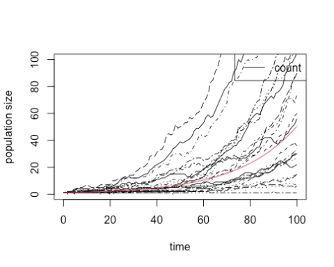

especially if you used these parameters:

```r
this.birth.rate <- 0.06
this.death.rate <- 0.02
initial.count <- 1
```

What happens to the variability as you increase the initial population size? You may want to adjust the scale of the y-axis to see what happens at larger population sizes. To automate this, you can set the y-axis upper limit to $100 \times$ `initial.count` by setting `ylim = c(0, 100 * initial.count)`. Report these results in your demo.